# Multiple Testing

## Significance Testing Mistakes

Mistake #1: Concluding there IS an effect when there IS NOT actually an effect.

```r
set.seed(10)
nn <- 10
group1.mean <- 6
group2.mean <- 6
yy <- c(rnorm(nn, group1.mean, 1),rnorm(nn, group2.mean, 1))
gg <- c(rep('a',nn), rep('b',nn))
summary(lm(yy ~ gg))$coefficients
```

```
##              Estimate Std. Error   t value                Pr(>|t|)
## (Intercept) 5.5093432  0.2167578 25.417051 0.000000000000001483964
## ggb         0.8602484  0.3065418  2.806301 0.011677945900063151086
```

This is a Type I error = A false positive = A false discovery

## Significance Testing Mistakes

Mistake #2: Concluding there IS NOT an effect when there IS actually an effect.

```r
set.seed(93)
nn <- 10
group1.mean <- 5
group2.mean <- 6
yy <- c(rnorm(nn, group1.mean, 1), rnorm(nn, group2.mean, 1))
gg <- c(rep('a', nn), rep('b', nn))
summary(lm(yy ~ gg))$coefficients
```

```
##              Estimate Std. Error   t value             Pr(>|t|)
## (Intercept) 5.5837026  0.3359147 16.622383 0.000000000002284901
## ggb         0.6398448  0.4750551  1.346885 0.194731320450884815
```

This is a Type II error = False Negative

## Types of errors and statistical power

|  | Reject H<sub>0</sub> | Fail to reject H<sub>0</sub> |
| --- | --- | --- |
| H<sub>0</sub> is true | Type I error | *Correct* |
| H<sub>0</sub> is false | *Correct* | Type II error |

Type I error occurs when:

- *P* is small by *random chance*, given that \(\alpha\) is chosen ahead of the test

Type II error probability depends on:

- The value of \(\alpha\)
- How “wrong” H<sub>0</sub> is

## Problems of Multiplicity

If you set a Type I error rate (\(\alpha\)) of 0.05 for any one test and then perform more than one such test on related data:

- The overall Type I error rate for all your tests together (familywise) is greater than 0.05
- You will be more likely than 5% to erroneously reject a *true* null hypothesis.
- You will claim a significant effect when one does not exist.

## Problems of Multiplicity

```r
set.seed(3210)
nn <- 10
group1.mean <- 6
group2.mean <- 6
niter <- 1000
ps<-data.frame('p1' = numeric(length = niter),
               'p2' = numeric(length = niter))

for(ii in 1:niter) {
  yy1 <- c(rnorm(nn, group1.mean, 1),rnorm(nn, group2.mean, 1))
  yy2 <- c(rnorm(nn, group1.mean, 1),rnorm(nn, group2.mean, 1))
  gg <- c(rep('a',nn), rep('b',nn))
  ps[ii,1] <- summary(lm(yy1 ~ gg))$coefficients[2,4]
  ps[ii,2] <- summary(lm(yy2 ~ gg))$coefficients[2,4]
}
```

## Problems of Multiplicity

What is the probability of a false positive for yy1?

```r
mean(ps[, 'p1'] < 0.05)
```

```
## [1] 0.044
```

## Problems of Multiplicity

What is the probability of a false positive for yy2?

```r
mean(ps[, 'p2'] < 0.05)
```

```
## [1] 0.053
```

## Problems of Multiplicity

What is the probability of a false positive for yy1 or yy2?

```r
sm.set <- ps[c(8, 12, 13), ]
sm.set$FP <- ifelse((sm.set[, 'p1'] < 0.05 | sm.set[, 'p2'] < 0.05),"Yes","No")

length(which(ps[, 'p1'] < 0.05 | ps[, 'p2'] < 0.05)) / niter
```

```
## [1] 0.095
```

The overall error rate = the family-wise error rate (FWER).

## Familywise Error Rate (FWER)

FWER is the probability that at least one test will reject a true null hypothesis, i.e., committing *at least one* type I error.

FWER is also sometimes termed

- Familywise Error (FEW)
- Experiment-wide error rate
- Experiment-wise error rate

We will use \(\alpha\) = 0.05 throughout, but the general principles apply to any \(\alpha\) (0.1, 0.05, 0.01, 0.001, etc.).

## Calculating FWER

For a family of \(k\) tests, where \(\alpha\) is the error rate for a single test:

\[\mbox{FWER} = 1-(1-\alpha)^k\]

For example, if you perform \(k = 20\) tests and judge them all at \(\alpha = 0.05\), then there is a 64% chance committing a type I error.

Note that:

\[\lim_{k \to \infty} (1 - \alpha)^k = 0\]

And thus

\[\lim_{k \to \infty} \mbox{FWER} = 1\]

## Calculating FWER

```r
library(Rmpfr)
alpha <- 0.05
1 - ((1 - alpha) ^ 20)
```

```
## [1] 0.6415141
```

```r
1 - ((1 - alpha) ^ 100)
```

```
## [1] 0.9940795
```

```r
options(scipen=0)
mpfr(1 - mpfr(((1 - alpha) ^ 1000), 128),128)
```

```
## 1 'mpfr' number of precision  128   bits
## [1] 0.9999999999999999999999470817725225519947
```

## Probability of a Type I Error

### from among a set of \(k\) total tests

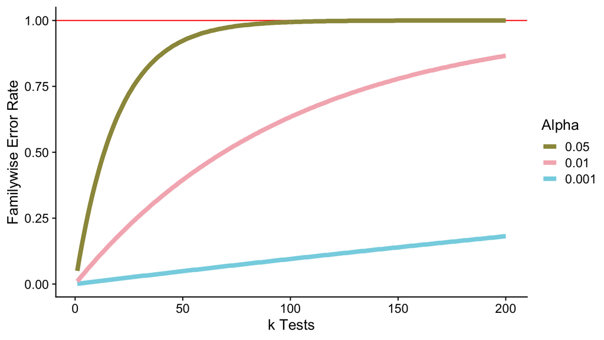

## A menu of MCPs

1. Do nothing
   - Not an option
2. Methods to control the Family-Wise Error Rate (FWER):
   - MCs within a single linear model (e.g. Tukey, etc.; see 08-2)
   - Bonferroni correction
     - Not recommended - overly conservative
   - Sequential Bonferroni procedure
   - Randomization procedures to empirically control FWER
3. Methods to control the False Discovery Rate (FDR)
   - False Discovery Rate Methods
   - *Positive* False Discovery Rate Methods

## Goals of multiple comparisons procedures

Type I and Type II errors will trade-off.

## General procedure

1. Complete an entire “family” of tests
   - A set of tests on related data
   - A single publication
   - A single thesis
   - All of science?
2. Collect the resulting *P* values into a single vector or `data.frame`.
3. Perform a multiple comparisons procedure (directly adjust or calculate new \(\alpha\) level)
4. Assess significance of your tests *as a whole*

## FWER vs. False discovery rate

Controlling FWER is appropriate when you want to guard against **any** false positives.

- When might this be appropriate?

In many cases we can live with a certain number of false positives.

If so, the more relevant quantity to control is the false discovery rate (FDR).

## False discovery rate

Proposed by Benjamini and Hochberg (1995).

- Also see Curran-Everett (2000).

Controls FDR (i.e., rate of Type I errors), rather than FWER

\[\mbox{FDR} = \frac{\mbox{n False Positives}}{\mbox{n All Positives}}\]

e.g., I’m OK with 5% false positives *among the tests I judge as significant*.

Note: False Positive Rate = \(\frac{\mbox{n False Positives}}{\mbox{n All Tests}}\)

## Distribution of *P* values

*P* values resulting from chance alone have a uniform distribution

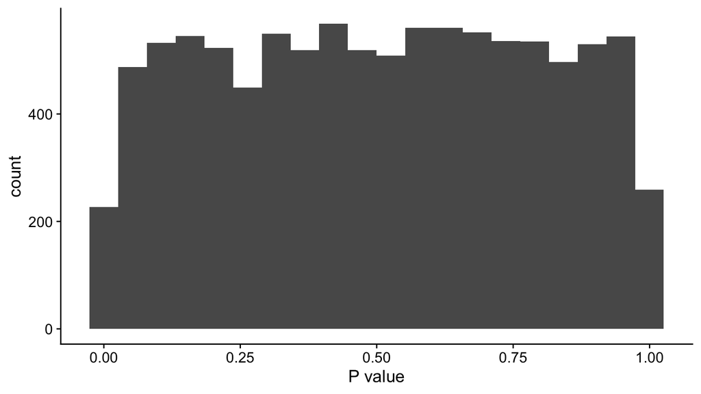

## Distribution of *P* values

*P* values resulting from chance alone have a uniform distribution

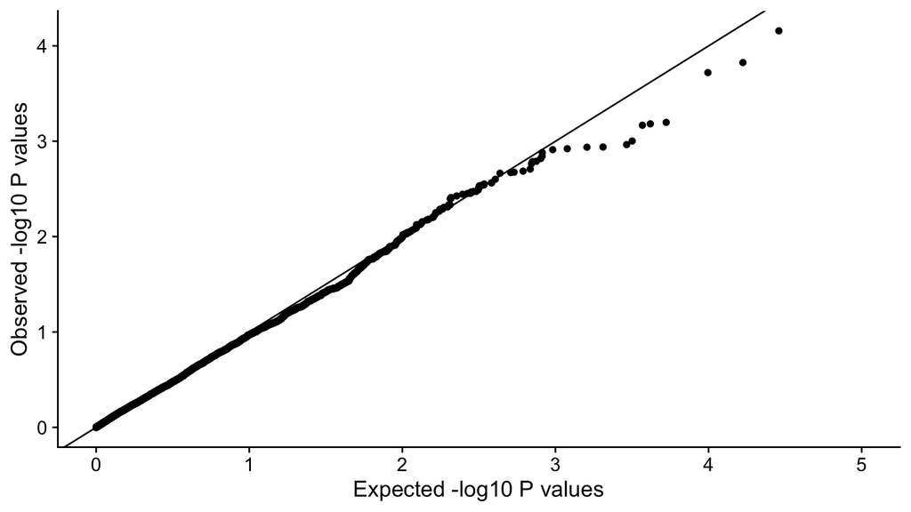

## Distribution of *P* values

*P* values resulting from chance alone have a uniform distribution

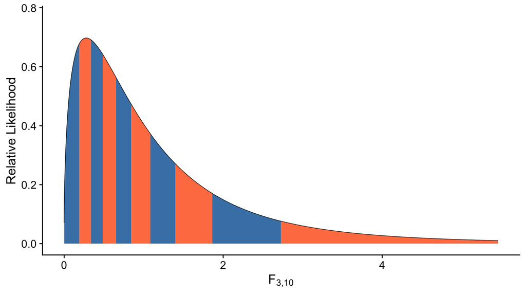

## Example *P* values to work with

### Turning kinematics in hummingbirds

```r
Ps <- read_excel("../data/P_values.xlsx")
glimpse(Ps)
```

```
## Rows: 203
## Columns: 1
## $ P <dbl> 6.984504e-02, 2.141840e-05, 1.624760e-01, 1.450266e-02, 6.355774e-0…
```

```r
range(Ps$P)
```

```
## [1] 1.000000e-16 9.916772e-01
```

203 *P* values. Range: 10<sup>-16</sup> to 0.992

## Example *P* values to work with

### Turning kinematics in hummingbirds

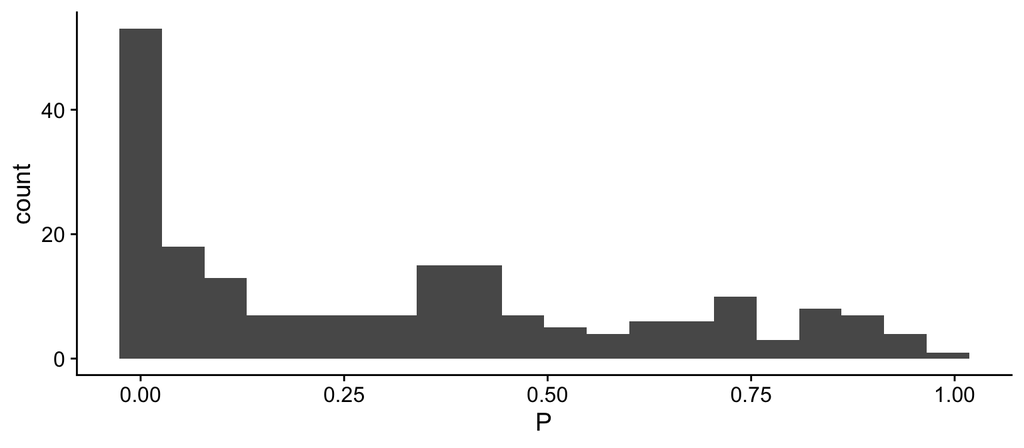

We have disproportionately more nominally significant tests. Otherwise relatively uniform.

## Distribution of *P* values

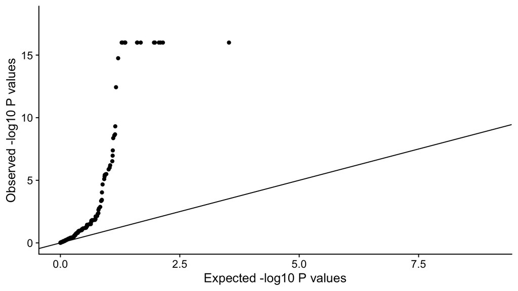

## Sort *P* values

It will be easier to follow the procedures if the rows are sorted smallest to largest:

```r
Ps <- Ps %>% arrange(P)
head(Ps)
```

```
## # A tibble: 6 x 1
##          P
##      <dbl>
## 1 1.00e-16
## 2 1.00e-16
## 3 1.00e-16
## 4 1.00e-16
## 5 1.00e-16
## 6 1.00e-16
```

## Sequential Bonferroni

- Sort the *P* values from smallest (\(p_1\)) to largest (\(p_k\))
- Start with the smallest (\(i = 1\)), and evaluate the inequality:

\[p_i \leq \frac{\alpha}{k - i + 1}\]

- If the inequality is *true*, call that test significant
- No difference from the the Bonferroni correction yet.
  - Step 1 equals Bonferroni correction

## Sequential Bonferroni

- Repeat for \(i = 2, 3, 4, \dots\), up to \(i = k\).
- At each step, the test value increases:

```r
0.05 / 203
```

```
## [1] 0.0002463054
```

```r
0.05 / 202
```

```
## [1] 0.0002475248
```

The last observed *P* value is compared to \(\alpha\).

## Sequential Bonferroni

If the inequality is *ever* false:

- Stop.
- Fail to reject that test.
- Fail to reject all remaining tests (because the list is sorted)

This and standard Bonferroni are “step-up” methods (start at the smallest and work up).

## R’s `p.adjust()` function

`p.adjust()` can do some multiple comparisons procedures, given a vector of *P*.

```r
Ps$Seq_Bonf <- p.adjust(Ps$P, "holm") < 0.05   # Sequential Bonferroni
sum(Ps$Seq_Bonf)
```

```
## [1] 33
```

Only 33 of the original 62 significant tests remain.

## False discovery rate

- Sort the *P* values from largest (\(p_k\)) to smallest (\(p_1\))
- Starting at the *largest* *P* value (\(p_k\)), calculate the critical significance level (\(d_k^*\)) for that *P* value:

\[d_k^* = q^* \frac{k}{k}\]

Where \(q^*\) is the desired false discovery rate (e.g., 0.05).

- If \(p_k \leq d_k^*\), then reject the null hypothesis for this and all remaining tests.
  - 1st comparison is vs. \(q^*\)
  - Rarely will the largest *P* value be less than \(q^*\).

## False discovery rate

- Move to the 2nd largest *P* value and calculate the critical significance level

\[d_k^* = q^* \frac{k - 1}{k}\]

- 2nd test vs. \(q^* \times 202/203 = 0.04975\)
- Continue until \(p_k \leq d_k^*\) then call that and all remaining tests (smaller *P* values) significant.
  - Last test vs. \(q^* \times 1/203 = 0.00025\) (Bonferroni)

“Step-down” method

## False discovery rate

```r
Ps$FDR <- p.adjust(Ps$P, "fdr") < 0.05
sum(Ps$FDR)
```

```
## [1] 44
```

44 of the original 62 significant tests remain.

## False discovery rate

```r
Ps %>% slice(32:47)
```

```
## # A tibble: 16 x 3
##            P Seq_Bonf FDR
##        <dbl> <lgl>    <lgl>
##  1 0.0000214 TRUE     TRUE
##  2 0.0000928 TRUE     TRUE
##  3 0.000365  FALSE    TRUE
##  4 0.000390  FALSE    TRUE
##  5 0.000407  FALSE    TRUE
##  6 0.000448  FALSE    TRUE
##  7 0.00133   FALSE    TRUE
##  8 0.00174   FALSE    TRUE
##  9 0.00231   FALSE    TRUE
## 10 0.00421   FALSE    TRUE
## 11 0.00482   FALSE    TRUE
## 12 0.00706   FALSE    TRUE
## 13 0.00771   FALSE    TRUE
## 14 0.0124    FALSE    FALSE
## 15 0.0126    FALSE    FALSE
## 16 0.0145    FALSE    FALSE
```

## Positive false discovery rate

- First method to deal with actual distribution of *P* values from the study in question.
  - This is a major advance.
- “Positive” refers to the fact that positive findings have occurred (rejection of null hypotheses).
- But which of these apparent positive findings are actually false (i.e., which are most likely Type I errors)?

## Goals of pFDR

Seek a balance between false positives and true positives

- Assume that we are doing an experiment because we expect some non-zero number of true positives.
  - Otherwise, why would we bother doing the experiment?
- We will accept a pFDR of 0.05 or 0.10, meaning that 5% or 10% of the tests we call true (nominally statistically significant) are actually false.

## Positive false discovery rate

Estimate \(\pi_0\) (ratio of true null tests to total tests) *from the distribution of P values*

- Other multiple comparison procedures assume that \(\pi_0 = 1\).

\[\pi_0 = \frac{\mbox{n True Null Tests}}{\mbox{n Total Tests}}\]

- FDR = pFDR when \(\pi_0 = 1\)
- More powerful than Bonferroni, sequential Bonferroni or FDR approaches
  - But the underlying assumptions of FDR and pFDR differ from Bonferroni and sequential Bonferroni

## pFDR and the `qvalue` package

pFDR is implemented in `qvalue`. Installation is a little different, because it is not in CRAN.

```r
source("https://bioconductor.org/biocLite.R")
biocLite("qvalue")
library(qvalue)
```

## \(\pi_0 = 1\)

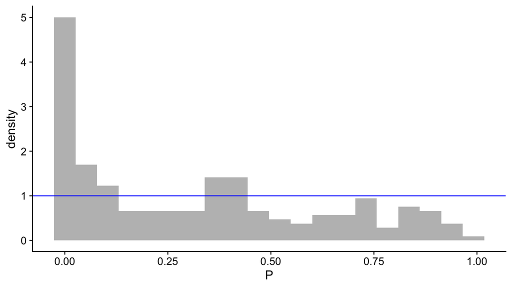

If all H<sub>0</sub> are true, you expect all bars to fall on the blue line.

## Estimation of \(\pi_0\)

- True non-null *P* values will fall nearest 0 (in the first bin: 0 - 0.05).
- Remaining *P* values will be uniformly distributed 0.05 - 1.00.
- Height of the uniform portion of the distribution estimates \(\pi_0\)
  - \(\pi_0\) falls in the range 0 to 1, where 1 equal FDR.
  - Follow the math in Storey & Tibshirani (2003) if you wish

## The \(q\) value

\(q\) is the the minimum FDR that can be attained when calling *that test significant*

- Each *P* value is associated with a \(q\) value
- A *P* value associated with a \(q\) value of 0.05 means that 5% of *P* values lower are expected to be false positives
  - In other words, consider a *P* value with an associated \(q\) value of 0.05. That *P* value and those lower than it should have a false positive rate of 0.05.

## pFDR in practice

Look at the distribution of your *P* values.

- The first bin should be largest (you have positive results)
- If the distribution is completely flat, you can’t use pFDR
- If the distribution looks like a normal curve, is skewed to the right, or has peaks near 0 and 1, then \(\pi_0\) estimation will probably fail. Fall back to FDR or sequential Bonferroni.

## pFDR in practice

For large numbers of *P* values (hundreds?, thousands?), the default settings in the qvalue package work fine:

- `lambda = seq(0, 0.90, 0.05)`
- `pi0.method = "smoother"`
- This estimates \(\pi_0\) across a sequence of tuning parameters (lambda) using a smoother to determine the optimal \(\pi_0\)
- If the smoother method fails, try `pi0.method = "bootstrap"` and/or `pdfr = TRUE`

## pFDR in practice

Just pass a vector of *P* values to `qvalue()`:

```r
qobj <- qvalue(Ps$P)
```

Explicitly:

```r
qobj <- qvalue(Ps$P, fdr.level = 0.05, pi0.method = "smoother")
```

## pFDR in practice

```r
summary(qobj)
```

```
##
## Call:
## qvalue(p = Ps$P)
##
## pi0: 0.325085
##
## Cumulative number of significant calls:
##
##           <1e-04 <0.001 <0.01 <0.025 <0.05 <0.1  <1
## p-value       33     37    44     53    62   78 203
## q-value       32     37    42     52    61   84 203
## local FDR     28     32    34     38    40   46 203
```

## Visualizing \(\pi_0 = 0.325\)

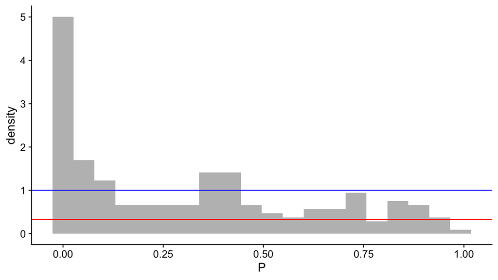

Blue: All H<sub>0</sub> are true. Red: Only 32% of H<sub>0</sub> are true.

## Calculating an adjusted \(\alpha\) level

```r
max(qobj$pvalues[qobj$qvalues <= 0.05])
```

```
## [1] 0.03957791
```

- *Translation*: Find the largest *P* value in `qobj` which has an associated \(q\) value less than or equal to 0.05.
  - So, if you use 0.03957791 as the \(\alpha\) level across all of your *P* values in this example, then you will be controlling the FDR at 0.05.

Include unadjusted *P* values and adjust \(\alpha\). Discuss results with respect to adjusted \(\alpha\).

## Positive false discovery rate

```r
Ps$pFDR <- qobj$qvalues < 0.05
sum(Ps$pFDR)
```

```
## [1] 61
```

61 of the original 62 significant tests remain.

## Positive false discovery rate

```r
Ps %>% slice(32:47)
```

```
## # A tibble: 16 x 4
##            P Seq_Bonf FDR   pFDR
##        <dbl> <lgl>    <lgl> <lgl>
##  1 0.0000214 TRUE     TRUE  TRUE
##  2 0.0000928 TRUE     TRUE  TRUE
##  3 0.000365  FALSE    TRUE  TRUE
##  4 0.000390  FALSE    TRUE  TRUE
##  5 0.000407  FALSE    TRUE  TRUE
##  6 0.000448  FALSE    TRUE  TRUE
##  7 0.00133   FALSE    TRUE  TRUE
##  8 0.00174   FALSE    TRUE  TRUE
##  9 0.00231   FALSE    TRUE  TRUE
## 10 0.00421   FALSE    TRUE  TRUE
## 11 0.00482   FALSE    TRUE  TRUE
## 12 0.00706   FALSE    TRUE  TRUE
## 13 0.00771   FALSE    TRUE  TRUE
## 14 0.0124    FALSE    FALSE TRUE
## 15 0.0126    FALSE    FALSE TRUE
## 16 0.0145    FALSE    FALSE TRUE
```

## A menu of MCPs

1. Do nothing
   - Not an option
2. Methods to control the Family-Wise Error Rate (FWER):
   - MCs within a single linear model (e.g. Tukey, etc.; see 08-2)
   - Bonferroni correction
     - Not recommended - overly conservative
   - Sequential Bonferroni procedure
   - Randomization procedures to empirically control FWER
3. Methods to control the False Discovery Rate (FDR)
   - False Discovery Rate Methods
   - *Positive* False Discovery Rate Methods

## Problems of Multiplicity

A general failing to account for multiplicity of tests is one of the reasons experiments do not replicate

- Philosophical issues
  - Scale:
    - What about multiple tests in one experiment?
    - What about multiple tests in one thesis?
  - Bayesians don’t need accounting: Gelman et al. (2012)
- Mathematical issues
  - Simultaneous corrections for thousands of tests

## References

Benjamini, Y., and Y. Hochberg. 1995. Controlling the False Discovery Rate: A Practical and Powerful Approach to Multiple Testing. *J. R. Stat. Soc. Series B Stat. Methodol.* 57:289–300.

Gelman, A., J. Hill, and M. Yajima. 2012. Why We (Usually) Don’t Have to Worry about Multiple Comparisons. *J. Res. Educ. Eff.* 5:189–211.

Storey, J. D., and R. Tibshirani. 2003. Statistical Significance for Genomewide Studies. *Proc. Natl. Acad. Sci. U. S. A.* 100:9440–9445.